# BMW VS VOLSKWAGEN: GARCH y VAR

Sara Bengoechea Rodríguez

# MODELO GARCH

Para comenzar, importamos los datos de los rendimientos de BMW de la librería Quantmod desde 2014 hasta el fin de Noviembre de 2020.

Obtenemos los rendimientos diarios y, mediante los siguientes gráficos, observamos la evolución del precio, de la rentabilidad y de la volatilidad a lo largo de los años:

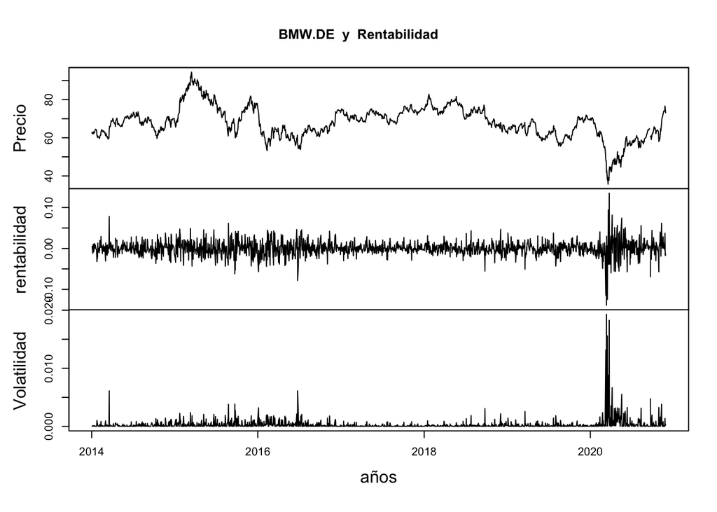

Realizamos un t.test de los rendimientos diarios para la media donde obtenemos un p-valor grande, por lo que aceptamos la hipótesis nula, significando que la verdadera media es igual a cero.

```
##
##  One Sample t-test
##
## data:  dRentCont
## t = 0.21196, df = 1748, p-value = 0.8322
## alternative hypothesis: true mean is not equal to 0
## 95 percent confidence interval:
##  -0.0007406791  0.0009201661
## sample estimates:
##   mean of x
## 8.97435e-05
```

Para la identificación y diagnosis del modelo GARCH realizamos ACF y PACF de los rendimientos al cuadrado. Podemos ver que no se trata de ruido blanco mediante los gráficos ACF Y PACF y con el test de Ljung-Box.

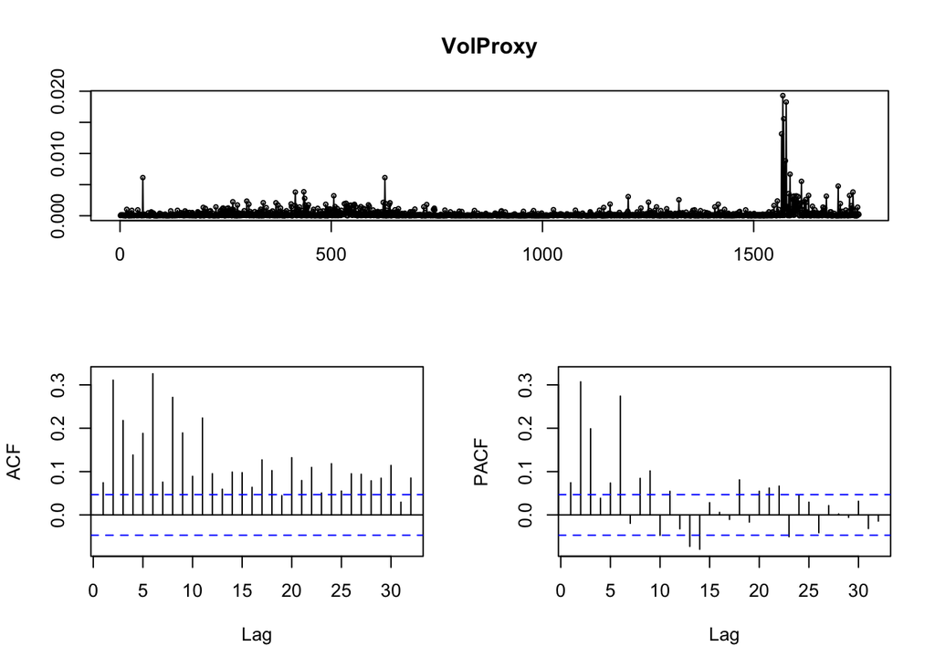

```
##
##  Box-Ljung test
##
## data:  VolProxy
## X-squared = 760.79, df = 10, p-value < 2.2e-16
```

```
##
##  Box-Ljung test
##
## data:  VolProxy
## X-squared = 993.66, df = 20, p-value < 2.2e-16
```

```
##
##  Box-Ljung test
##
## data:  VolProxy
## X-squared = 1230.8, df = 40, p-value < 2.2e-16
```

Test de Multiplicadores de Langrage de Engle (LM).

En este test, la hipótesis nula es de no GARCH. Dado el valor tan cercano a cero del p-valor, rechazamos la hipótesis nula y concluimos que podemos realizar un modelo de GARCH para el caso de BMW.

```
##
## Call:
## lm(formula = atsq ~ x)
##
## Residuals:
##        Min         1Q     Median         3Q        Max
## -0.0047684 -0.0002218 -0.0001073  0.0000544  0.0181166
##
## Coefficients:
##               Estimate Std. Error t value Pr(>|t|)
## (Intercept)  9.000e-05  2.557e-05   3.519 0.000444 ***
## x1          -3.635e-02  2.416e-02  -1.505 0.132576
## x2           2.366e-01  2.417e-02   9.787  < 2e-16 ***
## x3           9.265e-02  2.479e-02   3.738 0.000192 ***
## x4          -1.179e-02  2.490e-02  -0.474 0.635720
## x5           8.426e-02  2.489e-02   3.386 0.000726 ***
## x6           2.478e-01  2.497e-02   9.921  < 2e-16 ***
## x7          -2.280e-02  2.559e-02  -0.891 0.373151
## x8           1.235e-01  2.552e-02   4.839 1.42e-06 ***
## x9           7.497e-02  2.568e-02   2.919 0.003553 **
## x10         -4.162e-02  2.568e-02  -1.621 0.105223
## x11          7.900e-02  2.568e-02   3.076 0.002130 **
## x12         -4.406e-02  2.569e-02  -1.715 0.086478 .
## x13         -8.408e-02  2.554e-02  -3.291 0.001017 **
## x14         -8.908e-02  2.562e-02  -3.476 0.000521 ***
## x15          1.820e-02  2.511e-02   0.725 0.468544
## x16         -1.169e-02  2.503e-02  -0.467 0.640494
## x17         -7.626e-03  2.503e-02  -0.305 0.760654
## x18          6.754e-02  2.492e-02   2.710 0.006793 **
## x19         -1.440e-02  2.431e-02  -0.592 0.553891
## x20          5.537e-02  2.430e-02   2.278 0.022826 *
## ---
## Signif. codes:  0 '***' 0.001 '**' 0.01 '*' 0.05 '.' 0.1 ' ' 1
##
## Residual standard error: 0.0008736 on 1708 degrees of freedom
## Multiple R-squared:  0.2415, Adjusted R-squared:  0.2326
## F-statistic: 27.19 on 20 and 1708 DF,  p-value: < 2.2e-16
```

Ajustamos el modelo de ARCH(1). Su BIC es de -5.278798.

```
##
## Title:
##  GARCH Modelling
##
## Call:
##  garchFit(formula = ~1 + garch(1, 0), data = dRentCont, trace = F)
##
## Mean and Variance Equation:
##  data ~ 1 + garch(1, 0)
## <environment: 0x7f830172cb20>
##  [data = dRentCont]
##
## Conditional Distribution:
##  norm
##
## Coefficient(s):
##         mu       omega      alpha1
## 0.00017675  0.00023059  0.31682254
##
## Std. Errors:
##  based on Hessian
##
## Error Analysis:
##         Estimate  Std. Error  t value Pr(>|t|)
## mu     0.0001767   0.0003909    0.452    0.651
## omega  0.0002306   0.0000104   22.178  < 2e-16 ***
## alpha1 0.3168225   0.0454585    6.969 3.18e-12 ***
## ---
## Signif. codes:  0 '***' 0.001 '**' 0.01 '*' 0.05 '.' 0.1 ' ' 1
##
## Log Likelihood:
##  4627.509    normalized:  2.645803
##
## Description:
##  Mon Nov 30 23:22:40 2020 by user:
##
##
## Standardised Residuals Tests:
##                                 Statistic p-Value
##  Jarque-Bera Test   R    Chi^2  3745.216  0
##  Shapiro-Wilk Test  R    W      0.9376284 0
##  Ljung-Box Test     R    Q(10)  22.49945  0.01275285
##  Ljung-Box Test     R    Q(15)  30.67453  0.009708666
##  Ljung-Box Test     R    Q(20)  36.29074  0.01421393
##  Ljung-Box Test     R^2  Q(10)  319.1775  0
##  Ljung-Box Test     R^2  Q(15)  383.6313  0
##  Ljung-Box Test     R^2  Q(20)  475.3133  0
##  LM Arch Test       R    TR^2   232.4751  0
##
## Information Criterion Statistics:
##       AIC       BIC       SIC      HQIC
## -5.288175 -5.278798 -5.288181 -5.284709
```

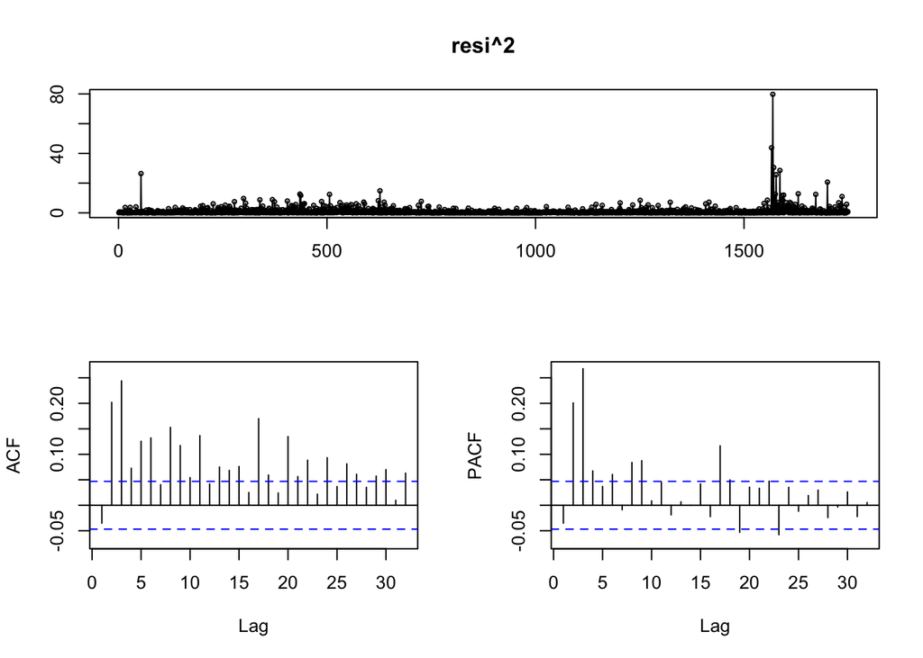

Ajustamos el modelo de GARCH(1,1). Su BIC es de -5.471159, menor que el del ARCH(1), por lo que es un modelo más adecuado que el anterior.

```
##
## Title:
##  GARCH Modelling
##
## Call:
##  garchFit(formula = ~1 + garch(1, 1), data = dRentCont, trace = F)
##
## Mean and Variance Equation:
##  data ~ 1 + garch(1, 1)
## <environment: 0x7f8304c959a8>
##  [data = dRentCont]
##
## Conditional Distribution:
##  norm
##
## Coefficient(s):
##         mu       omega      alpha1       beta1
## 3.0532e-04  2.5007e-06  4.9894e-02  9.4273e-01
##
## Std. Errors:
##  based on Hessian
##
## Error Analysis:
##         Estimate  Std. Error  t value Pr(>|t|)
## mu     3.053e-04   3.360e-04    0.909   0.3635
## omega  2.501e-06   9.781e-07    2.557   0.0106 *
## alpha1 4.989e-02   8.002e-03    6.235  4.5e-10 ***
## beta1  9.427e-01   9.548e-03   98.734  < 2e-16 ***
## ---
## Signif. codes:  0 '***' 0.001 '**' 0.01 '*' 0.05 '.' 0.1 ' ' 1
##
## Log Likelihood:
##  4799.462    normalized:  2.744118
##
## Description:
##  Mon Nov 30 23:22:41 2020 by user:
##
##
## Standardised Residuals Tests:
##                                 Statistic p-Value
##  Jarque-Bera Test   R    Chi^2  749.4246  0
##  Shapiro-Wilk Test  R    W      0.9722568 0
##  Ljung-Box Test     R    Q(10)  21.9004   0.01562014
##  Ljung-Box Test     R    Q(15)  26.40683  0.03395787
##  Ljung-Box Test     R    Q(20)  32.28662  0.04033832
##  Ljung-Box Test     R^2  Q(10)  21.35063  0.01877703
##  Ljung-Box Test     R^2  Q(15)  22.86262  0.08710055
##  Ljung-Box Test     R^2  Q(20)  26.26798  0.1571427
##  LM Arch Test       R    TR^2   21.86675  0.03904063
##
## Information Criterion Statistics:
##       AIC       BIC       SIC      HQIC
## -5.483661 -5.471159 -5.483672 -5.479039
```

Analizamos el error del modelo GARCH(1,1) y vemos que no es un caso de ruido blanco.

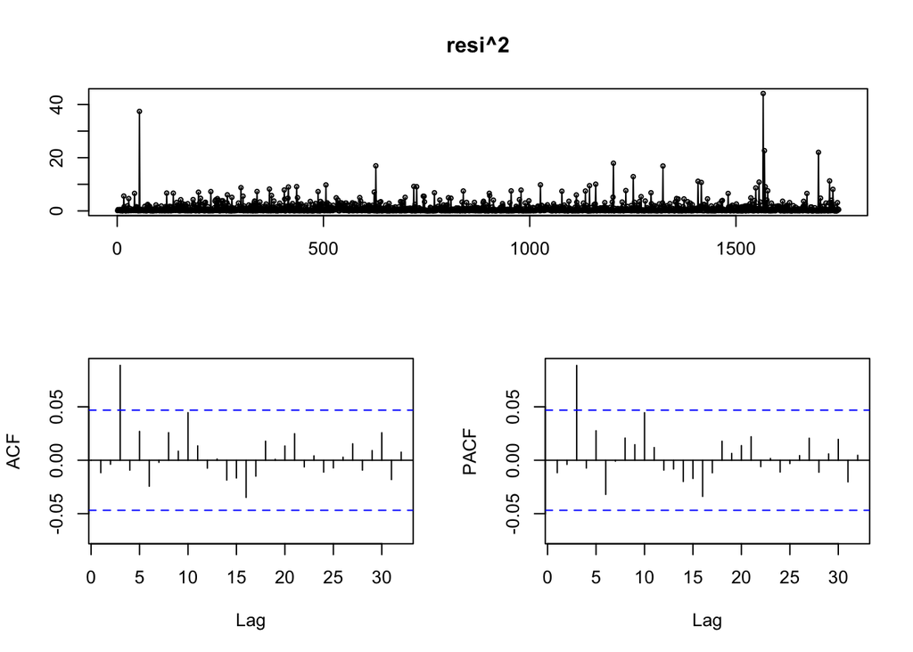

Procedemos a realizar un modelo garch con conditional distribution. El BIC es de -5.549017, y se trata del menor BIC, por lo que el modelo final será este.

```
##
## Title:
##  GARCH Modelling
##
## Call:
##  garchFit(formula = ~1 + garch(1, 1), data = dRentCont, cond.dist = "std",
##     trace = F)
##
## Mean and Variance Equation:
##  data ~ 1 + garch(1, 1)
## <environment: 0x7f8303ff1868>
##  [data = dRentCont]
##
## Conditional Distribution:
##  std
##
## Coefficient(s):
##         mu       omega      alpha1       beta1       shape
## 3.8524e-06  2.0319e-06  4.6988e-02  9.4825e-01  4.9742e+00
##
## Std. Errors:
##  based on Hessian
##
## Error Analysis:
##         Estimate  Std. Error  t value Pr(>|t|)
## mu     3.852e-06   3.085e-04    0.012   0.9900
## omega  2.032e-06   9.632e-07    2.110   0.0349 *
## alpha1 4.699e-02   9.910e-03    4.741 2.12e-06 ***
## beta1  9.482e-01   1.047e-02   90.541  < 2e-16 ***
## shape  4.974e+00   6.058e-01    8.211 2.22e-16 ***
## ---
## Signif. codes:  0 '***' 0.001 '**' 0.01 '*' 0.05 '.' 0.1 ' ' 1
##
## Log Likelihood:
##  4871.282    normalized:  2.785181
##
## Description:
##  Mon Nov 30 23:22:42 2020 by user:
##
##
## Standardised Residuals Tests:
##                                 Statistic p-Value
##  Jarque-Bera Test   R    Chi^2  779.926   0
##  Shapiro-Wilk Test  R    W      0.9718859 0
##  Ljung-Box Test     R    Q(10)  22.09689  0.01461855
##  Ljung-Box Test     R    Q(15)  26.50925  0.03299867
##  Ljung-Box Test     R    Q(20)  32.38958  0.03931994
##  Ljung-Box Test     R^2  Q(10)  24.82233  0.005692648
##  Ljung-Box Test     R^2  Q(15)  26.31576  0.03483185
##  Ljung-Box Test     R^2  Q(20)  29.88551  0.07173019
##  LM Arch Test       R    TR^2   25.36204  0.01319746
##
## Information Criterion Statistics:
##       AIC       BIC       SIC      HQIC
## -5.564645 -5.549017 -5.564661 -5.558868
```

Obtenemos la volatilidad de nuestro modelo final que sigue el siguiente gráfico. Se puede observar cómo aumenta la volatilidad en 2020 debido al coronavirus, ya que el sector automovilístico fue uno de los más afectados.

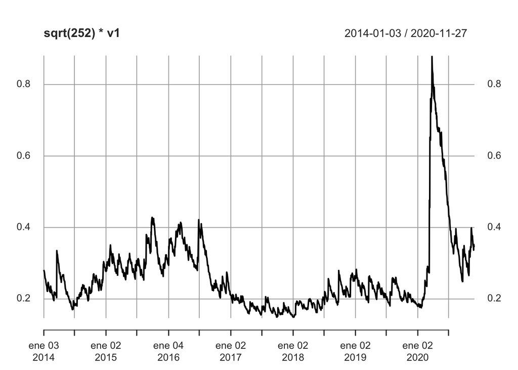

Estudiamos los errores del modelo y vemos que tampoco son ruido blanco.

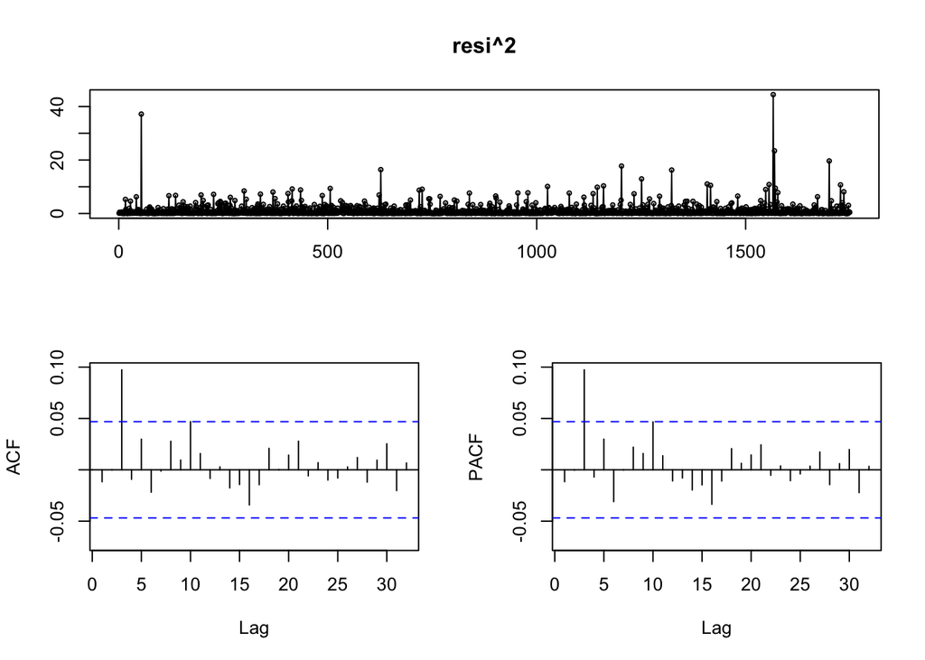

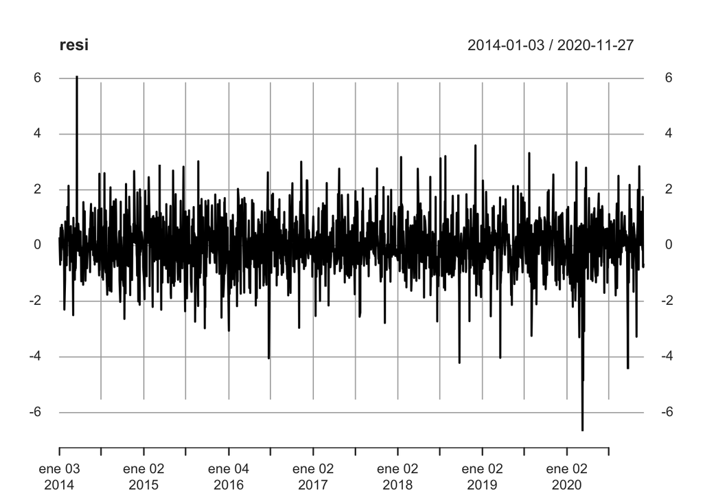

Realizamos la predicción de nuestro mejor modelo. El siguiente es la predicción para el modelo GARCH para 10 lags con un valor crítico de 2.

| meanForecast | meanError | standardDeviation |
| --- | --- | --- |
| 3.85243e-06 | 0.02145798 | 0.02145798 |
| 3.85243e-06 | 0.02145422 | 0.02145422 |
| 3.85243e-06 | 0.02145048 | 0.02145048 |
| 3.85243e-06 | 0.02144675 | 0.02144675 |
| 3.85243e-06 | 0.02144304 | 0.02144304 |
| 3.85243e-06 | 0.02143935 | 0.02143935 |
| 3.85243e-06 | 0.02143567 | 0.02143567 |
| 3.85243e-06 | 0.02143202 | 0.02143202 |
| 3.85243e-06 | 0.02142837 | 0.02142837 |
| 3.85243e-06 | 0.02142475 | 0.02142475 |

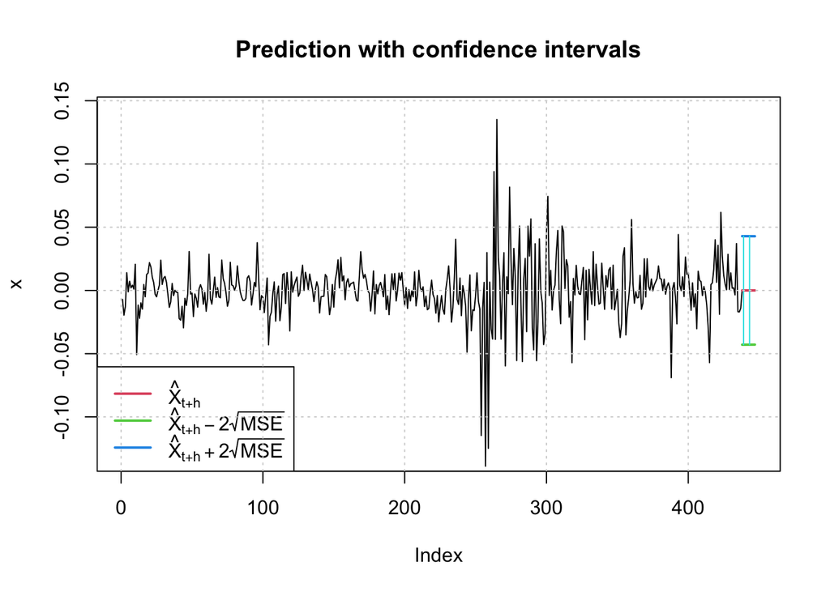

| meanForecast | meanError | standardDeviation | lowerInterval | upperInterval |
| --- | --- | --- | --- | --- |
| 3.85243e-06 | 0.02145798 | 0.02145798 | -0.04291212 | 0.04291982 |
| 3.85243e-06 | 0.02145422 | 0.02145422 | -0.04290459 | 0.04291230 |
| 3.85243e-06 | 0.02145048 | 0.02145048 | -0.04289711 | 0.04290481 |
| 3.85243e-06 | 0.02144675 | 0.02144675 | -0.04288965 | 0.04289736 |
| 3.85243e-06 | 0.02144304 | 0.02144304 | -0.04288223 | 0.04288994 |
| 3.85243e-06 | 0.02143935 | 0.02143935 | -0.04287485 | 0.04288255 |
| 3.85243e-06 | 0.02143567 | 0.02143567 | -0.04286750 | 0.04287520 |
| 3.85243e-06 | 0.02143202 | 0.02143202 | -0.04286018 | 0.04286788 |
| 3.85243e-06 | 0.02142837 | 0.02142837 | -0.04285289 | 0.04286060 |
| 3.85243e-06 | 0.02142475 | 0.02142475 | -0.04284564 | 0.04285335 |

La predicción del modelo GARCH para 20 lags, una confianza del 90% y de 100 observaciones sería como de la siguiente manera

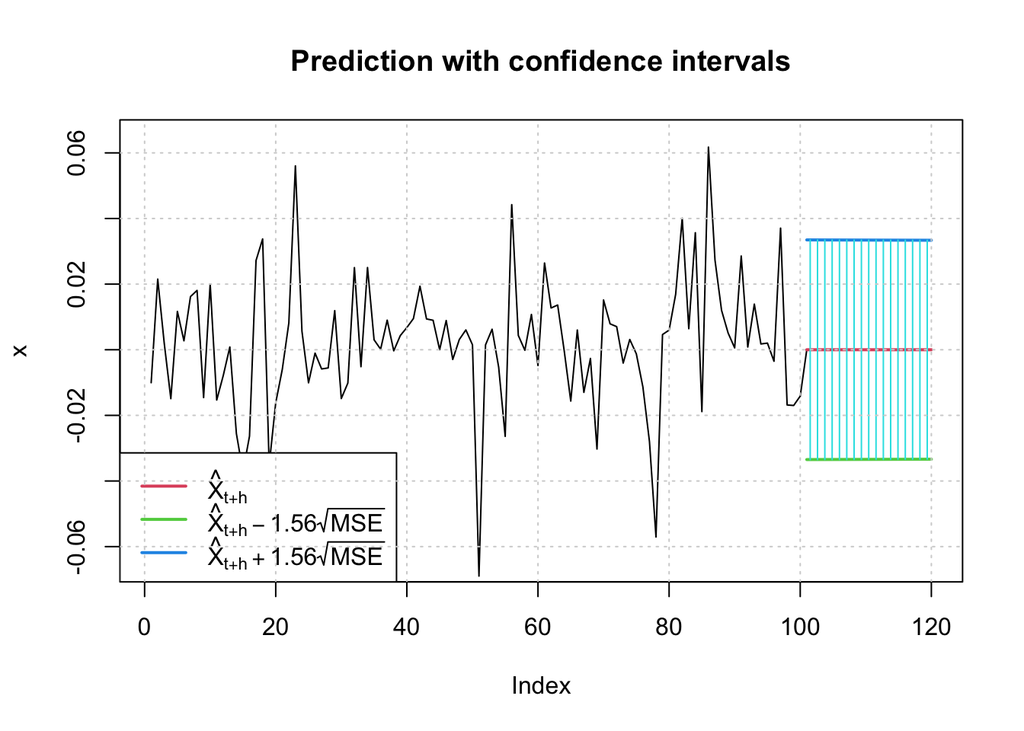

| meanForecast | meanError | standardDeviation | lowerInterval | upperInterval |
| --- | --- | --- | --- | --- |
| 3.85243e-06 | 0.02145798 | 0.02145798 | -0.03346920 | 0.03347690 |
| 3.85243e-06 | 0.02145422 | 0.02145422 | -0.03346333 | 0.03347103 |
| 3.85243e-06 | 0.02145048 | 0.02145048 | -0.03345749 | 0.03346519 |
| 3.85243e-06 | 0.02144675 | 0.02144675 | -0.03345167 | 0.03345938 |
| 3.85243e-06 | 0.02144304 | 0.02144304 | -0.03344589 | 0.03345359 |
| 3.85243e-06 | 0.02143935 | 0.02143935 | -0.03344013 | 0.03344783 |
| 3.85243e-06 | 0.02143567 | 0.02143567 | -0.03343439 | 0.03344210 |
| 3.85243e-06 | 0.02143202 | 0.02143202 | -0.03342869 | 0.03343639 |
| 3.85243e-06 | 0.02142837 | 0.02142837 | -0.03342300 | 0.03343071 |
| 3.85243e-06 | 0.02142475 | 0.02142475 | -0.03341735 | 0.03342505 |

[output cut: 10 more lines]

# MODELO VAR

Para comenzar importamos los datos de BMW y Volskwagen de la librería quantmod, obtenemos los rendimientos mensuales de ambos activos, generamos vectores de estos y eliminamos los valores nulos.

Mediante la función VARselect() seleccionamos el mejor modelo según el AIC, HQ, SC y FPE. Atendiendo al AIC y FPE, el mejor modelo es de 10 retardos y al HQ y SC es de un solo retardo.

```
## $selection
## AIC(n)  HQ(n)  SC(n) FPE(n)
##     10      1      1     10
##
## $criteria
##                    1             2             3             4             5
## AIC(n) -9.0514147382 -9.0280744231 -9.0428347156 -9.0475455972 -9.0083470631
## HQ(n)  -9.0039784881 -8.9490140063 -8.9321501320 -8.9052368469 -8.8344141460
## SC(n)  -8.9346155354 -8.8334090852 -8.7703032425 -8.6971479890 -8.5800833197
## FPE(n)  0.0001172262  0.0001199985  0.0001182492  0.0001177091  0.0001224403
##                    6             7             8             9            10
## AIC(n) -9.0020079082 -8.9683856090 -8.9665173331 -8.9948651305 -9.0603597685
## HQ(n)  -8.7964508244 -8.7312043585 -8.6977119159 -8.6944355464 -8.7283060177
## SC(n)  -8.4958780296 -8.3843895953 -8.3046551842 -8.2551368464 -8.2427653492
## FPE(n)  0.0001232559  0.0001275227  0.0001278296  0.0001243412  0.0001165565
```

Estimamos el modelo con la función VAR y obtenemos los siguientes resultados. En la matriz de correlaciones podemos observar una correlación de los activos de 0.2996.

```
##
## VAR Estimation Results:
## =========================
## Endogenous variables: bmw, vlk
## Deterministic variables: const
## Sample size: 166
## Log Likelihood: 288.901
## Roots of the characteristic polynomial:
## 0.06285 0.06285
## Call:
## VAR(y = vY)
##
##
## Estimation results for equation bmw:
## ====================================
## bmw = bmw.l1 + vlk.l1 + const
##
##         Estimate Std. Error t value Pr(>|t|)
## bmw.l1  0.007854   0.082478   0.095   0.9243
## vlk.l1 -0.092834   0.055323  -1.678   0.0953 .
## const   0.010502   0.006722   1.562   0.1202
## ---
## Signif. codes:  0 '***' 0.001 '**' 0.01 '*' 0.05 '.' 0.1 ' ' 1
##
##
## Residual standard error: 0.08594 on 163 degrees of freedom
## Multiple R-Squared: 0.01789, Adjusted R-squared: 0.00584
## F-statistic: 1.485 on 2 and 163 DF,  p-value: 0.2296
##
##
## Estimation results for equation vlk:
## ====================================
## vlk = bmw.l1 + vlk.l1 + const
##
##        Estimate Std. Error t value Pr(>|t|)
## bmw.l1  0.04442    0.12245   0.363    0.717
## vlk.l1 -0.02200    0.08214  -0.268    0.789
## const   0.01334    0.00998   1.337    0.183
##
##
## Residual standard error: 0.1276 on 163 degrees of freedom
## Multiple R-Squared: 0.0009896,   Adjusted R-squared: -0.01127
## F-statistic: 0.08073 on 2 and 163 DF,  p-value: 0.9225
##
##
##
## Covariance matrix of residuals:
##          bmw      vlk
## bmw 0.007386 0.003286
## vlk 0.003286 0.016281
##
## Correlation matrix of residuals:
##        bmw    vlk
## bmw 1.0000 0.2996
## vlk 0.2996 1.0000
```

Ajustamos de nuevo el modelo VAR pero esta vez no incluimos los regresores determinísticos (type = “none”). En este caso la correlación es de 0.2998, ligeramente superior.

```
##
## VAR Estimation Results:
## =========================
## Endogenous variables: bmw, vlk
## Deterministic variables: none
## Sample size: 166
## Log Likelihood: 287.253
## Roots of the characteristic polynomial:
## 0.06847 0.06847
## Call:
## VAR(y = vY, type = "none")
##
##
## Estimation results for equation bmw:
## ====================================
## bmw = bmw.l1 + vlk.l1
##
##        Estimate Std. Error t value Pr(>|t|)
## bmw.l1  0.01775    0.08259   0.215     0.83
## vlk.l1 -0.08666    0.05542  -1.564     0.12
##
##
## Residual standard error: 0.08632 on 164 degrees of freedom
## Multiple R-Squared: 0.01505, Adjusted R-squared: 0.003034
## F-statistic: 1.253 on 2 and 164 DF,  p-value: 0.2885
##
##
## Estimation results for equation vlk:
## ====================================
## vlk = bmw.l1 + vlk.l1
##
##        Estimate Std. Error t value Pr(>|t|)
## bmw.l1  0.05699    0.12238   0.466    0.642
## vlk.l1 -0.01415    0.08212  -0.172    0.863
##
##
## Residual standard error: 0.1279 on 164 degrees of freedom
## Multiple R-Squared: 0.00133, Adjusted R-squared: -0.01085
## F-statistic: 0.1092 on 2 and 164 DF,  p-value: 0.8966
##
##
##
## Covariance matrix of residuals:
##          bmw      vlk
## bmw 0.007343 0.003268
## vlk 0.003268 0.016184
##
## Correlation matrix of residuals:
##        bmw    vlk
## bmw 1.0000 0.2998
## vlk 0.2998 1.0000
```

```
## $Granger
##
##  Granger causality H0: bmw do not Granger-cause vlk
##
## data:  VAR object model.var1
## F-Test = 0.21685, df1 = 1, df2 = 328, p-value = 0.6418
##
##
## $Instant
##
##  H0: No instantaneous causality between: bmw and vlk
##
## data:  VAR object model.var1
## Chi-squared = 14.421, df = 1, p-value = 0.0001462
```

Los coeficientes de respuesta al impulso son los siguientes:

```
##
## Impulse response coefficients
## $bmw
##                 bmw           vlk
##  [1,]  8.631834e-02  3.945084e-02
##  [2,] -1.886470e-03  4.360964e-03
##  [3,] -4.114179e-04 -1.692393e-04
##  [4,]  7.362680e-06 -2.105163e-05
##  [5,]  1.955075e-06  7.175827e-07
##  [6,] -2.747860e-08  1.012647e-07
##  [7,] -9.263574e-09 -2.999388e-09
##  [8,]  9.547639e-11 -4.854858e-10
##  [9,]  4.376790e-11  1.231312e-11
## [10,] -2.900675e-13  2.320092e-12
## [11,] -2.062122e-13 -4.937105e-14
```

[output cut: 74 more lines]

Para el modelo VAR se lleva a cabo la siguiente predicción para 10 lags y ci = 0.95.

```
## $bmw
##                fcst      lower     upper        CI
##  [1,] -1.334896e-02 -0.1825298 0.1558319 0.1691808
##  [2,] -1.199175e-03 -0.1716776 0.1692792 0.1704784
##  [3,]  5.826013e-05 -0.1704221 0.1705386 0.1704803
##  [4,]  5.830947e-06 -0.1704745 0.1704862 0.1704803
##  [5,] -2.521211e-07 -0.1704806 0.1704801 0.1704803
##  [6,] -2.824063e-08 -0.1704804 0.1704803 0.1704803
##  [7,]  1.080235e-09 -0.1704803 0.1704803 0.1704803
##  [8,]  1.362691e-10 -0.1704803 0.1704803 0.1704803
##  [9,] -4.573413e-12 -0.1704803 0.1704803 0.1704803
## [10,] -6.552379e-13 -0.1704803 0.1704803 0.1704803
##
## $vlk
##                fcst      lower     upper        CI
##  [1,]  1.110289e-02 -0.2395798 0.2617856 0.2506827
##  [2,] -9.179271e-04 -0.2517690 0.2499332 0.2508511
##  [3,] -5.534941e-05 -0.2509092 0.2507985 0.2508539
##  [4,]  4.103750e-06 -0.2508498 0.2508580 0.2508539
##  [5,]  2.742251e-07 -0.2508536 0.2508542 0.2508539
##  [6,] -1.825017e-08 -0.2508539 0.2508539 0.2508539
##  [7,] -1.351140e-09 -0.2508539 0.2508539 0.2508539
##  [8,]  8.068844e-11 -0.2508539 0.2508539 0.2508539
##  [9,]  6.624011e-12 -0.2508539 0.2508539 0.2508539
## [10,] -3.544033e-13 -0.2508539 0.2508539 0.2508539
```